# Adimen Naturala1. mintegia: Adimen-edo Artifizial hori adimenez erabiliaz

Juan Abasolo

**Tip**

Aparatuok ur piloa eta energia ikaragarria kontsumitzen dute; datu zentroek ere bai. Horregatik, **erabilera arduratsua** egin behar da.

**Caution**

Datuen pribatutasuna eta segurtasuna kontuan hartu behar dira. **Ez erabili datu pertsonalik edo sentikorrik**.

**Note**

Gaurko saiorako interesgarria da aztertu beharreko dokumentuak izatea.

Landu beharreko eremua argi izatea ere bai.

📝 eta 💻 ere bai

hasierako oharrak

[figure not shown]

Coockieak onartu, gozo!! 🍪🍪🍪🍪🍪🍪🍪🍪🤮 tripahalak gero

# Sarrera

## Esperientziak

| PRO | CON |
| --- | --- |
| hau | beste |
| bai | ez |
| argi | ilun |
| … | ··· |

## Azalpenak

💬

Zuon esperientzien azalpenak, alegia

# Erreminta Vs Jakintza

## Erreminta ala “adimena”

Submarino nuklearrak baino hobeto buzeatu dezakezu?

Errobot batzuk montatutako automobila mekanikari batek konpontzea nahi dugu

## Humanizomorfismoa… marketing estrategia😍😻❤️

> AIk badaki hau eta beste

> ez daki horri buruz

> pentsatzen du honela eta hala

> halunizatzen du…

[figure not shown]

[+](https://www.youtube.com/watch?v=U6jXkV2XHkI)

# Funtzi⚙️namenduz

## Tokenak

https://platform.openai.com/tokenizer

Haur eta Lehen Hezkuntzako graduko ikasleak gara.

Deigarria da, dudarik gabe, nola saldu zaigun aparatu bat pertsona balitz bezala tratatzea. Agian hori izango da jendea gauzak balira bezala tratatzen hasteko.

Espero dut ez egitea

Somos estudiantes de grado de Educación Infantil y Primaria.

Es llamativo, sin duda, cómo se nos ha vendido que tratemos a un aparato como si fuera persona. Quizá sea eso sea para que nos pongamos a tratar a las personas como si fuéran cosas.

Espero que no lo hagamos

We are students of the Degree in Early Childhood and Primary Education.

It is striking, without a doubt, how we have been sold to treat a device as if it were a person. Maybe that is so that we start treating people as if they were things.

I hope we don’t do it

🤔 zein da luzeagoa?

## Dimentsio anitzeko espazioa

- Puntu (elementu) bik, lerroa
- Hiru puntuk, planoa
- Lau puntuk, bolumena
- Bost puntuk, 4D espazioa
- Seik puntuk, 5D espazioa 💣
- Zazpi …

## Testuinguruen modelizazio matematikoa

Tokenen arteko erlazioaren probabilitatearen eredu matematikoa.

Ez determinista.

**Ariketa**

Zuen txikitako eskolako testuinguru soziolinguistikoaz markoa idatzi behar duzue PIIIrako. Eskatu ChatGPTri hori egitea (eta aztertu sinesgarritasuna)

**Historia garbi**

Erabili “Tenporary chat” aukera, informazioa gorde nahi ez baduzu.

Segitzerik nahi ez baduzu, duck.ai

# Tresnetara🛠! 🦇

## Elkarrizketa

Irudiarekin etorritako testua:

Hona hemen eskatutako aldaketekin: Robin orain lehen planoan dago, akzio betean eta argi protagonista dela. Batwoman atzeraxeago dago, baina oraindik indartsu eta atletikoa, neurrizko proportzioekin. Espero dut irudi hau zure ikuspegiarekin bat etortzea! Beste aldaketarik nahi baduzu, esan lasai. 😊

Eta nire aurreko (eta azken) eskaera:

Ez. Lehenengo planoan Robin-emakumezkoa, ile ez hain laburrarekin. Bigarren planoan Batwoman ez da gazte-gaztetsua izango, baizik eta andrezko enpoderatua, ez zaizkiona saihtsak markatuko eta ez ditu izango bular ikaragarri handiak. Robin egongo denez lehenengo planoan, tapatu ahal du aput bat Batwomanen gorputza, normberak nahi duen antzera irudikatu ahal izateko.

## Zer jan, horren 💩 agertzen da

horrela da

## Ereduak eta aplikazioak

- DeepSeek
- GPT-4
- Claude 3
- Gemini
- LLaMA 3
- Mistral
- Perplexity
- YouChat
- NotebookLM
- ChatGPT
- Copilot
- Connected Papers

## Orokorrak

- Promptaren diseinua
- Temperatura
- Verbosity
- Roleak
- Leihoa 8000 token gaur

[figure not shown]

[figure not shown]

## Temperature | Verboxity | Role

[figure not shown]

Erantzuna osorik hemen [klik eginda](https://chat.deepseek.com/share/ek2k0praltk0nkv42t).

**Aurrekotik ekarritako ariketa**

[output not shown]

### OpenAI

- Pertsonalizazioa 🧑‍🦲*
- Testua + ahotsa
- GPT-ak [*](https://chatgpt.com/g/g-67c4db0728748191a08f8d358c2295d3-zientzia-laburketan)
- Proiektuak

### Proiektuak

[figure not shown]

### Ikerketa sakona

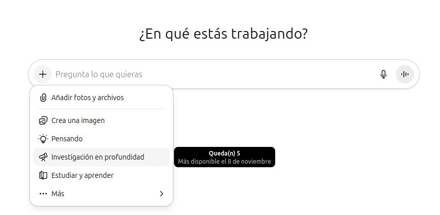

Debaldeko erabiltzailearekin ☝️horrela.

**Prompta aparte sortu**

Berez, OpenAI-k aukera gutxi batzuk ematen ditu (hilean 5), oso emankorra izan daiteke sistema hau erabiltzea, baina ez da inondik inora komeni erabili eta erabili ibiltzea.

💧ur kontsumoaz eta erabilera arduratsu ahaztuaz aparte 🏜️

## Perplexity

- Iturriak
- Pro research
- Pro erabiltzailea!!!

## NotebookLM

- Artikuluen lanketa
- Apunteen lanketa (Zotero hurrengorako aipatu)

Emandako iturrietan oinarrituta, William Shakespeareren zenbait obratan agertzen diren borondatezko heriotza, hilketa, exekuzio edo hiltze kasuen zenbaketa honako taula honetan aurkezten da (antzezlan barruko fikziozko heriotzak ere sartuta)

.

| Lana (Work) | Hilketa, Exekuzio edo Suizidio kopurua |
| --- | --- |
| *Antony and Cleopatra* | 4 |
| *Cymbeline, King of Britain* | 1 |
| *History of Henry IV, Part I* | 2 |
| *History of Henry IV, Part II* | 3 |
| *History of Henry V* | 4 |
| *History of Henry VI, Part I* | 5 |
| *History of Henry VI, Part II* | 4 |
| … | … |

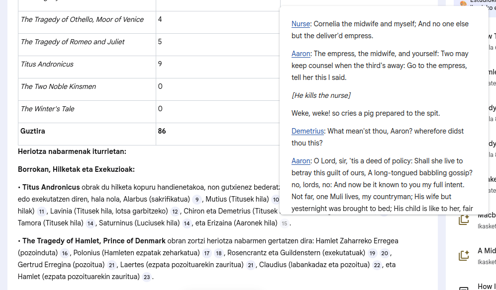

**Ariketa**

Aztertu zuok GrAL lanerako aukeratutako artikuluak.

Ez badaukazu oraindik aukeratuta, Shakespearerena azter dezakezu [hemen](https://notebooklm.google.com/notebook/19bde485-a9c1-4809-8884-e872b2b67b44); edota EAEko curriculum dekretuak, Espainikoak eta EEMBa eta Europako gomendioak [hemen](https://notebooklm.google.com/notebook/b284b970-dcbc-4a61-ba4a-b9dc4b2997dd)

## Ikerkuntzarako berezi diseinatutakoak 🔍

- Connected Papers
- Research Rabit
- Elicit
- …

[figure not shown]

Is it safe to use ChatGPT for your task? Aleksandr Tiulkanov

[+](https://unesdoc.unesco.org/ark:/48223/pf0000385146_spa)

[figure not shown]

[+](https://unesdoc.unesco.org/ark:/48223/pf0000385146_spa)

## ChatGPT, Google-Chrome eta zu eta zure datuak ehiza-gai

## Firefox

[figure not shown]

## Edge

[figure not shown]

## Firefox 🦊 ❤️

[figure not shown]

- Motorra aukeratu
- Inguru zarratuetan gorde ahal da (leiho pribatuen antzera, baina ugari)
- Ez du daturik bidaltzen berak berez

## Gida batzuk AA hezkuntzan-eta

Gure unibertsitatean, nonbait, egiten ibiliko dira; bitartean:

*Adimen Artifiziala Hezkuntzan* izeneko txostena duzue EJko webgunean, [esteka honetan](https://www.euskadi.eus/eusko-jaurlaritza/-/dokumentazioa/2025/dokumentu-eta-argitalpenak-adimen-artifiziala-hezkuntzan/), Elhuyarrek idatzitakoa da.

Hemen 🇫🇷 Hezkuntza eta Ikerketako Ministerioak egindakoa. [AAren erabilera Hezkuntzan](https://www.education.gouv.fr/cadre-d-usage-de-l-ia-en-education-450647).

Eta [hemen](https://www.coe.int/fr/web/education/artificial-intelligence) 🇪🇺 Europar Batasuneko webgunean kontu honen gaineko tartea.